# Telco Customer Churn

```
Please note that the order of codes, files and folders in this project has changed over time. Here are the steps I followed:
*   Searching,
*   Coding,
*   Analyzing the results and refining the approach,
Through repeated iterations, I have learned valuable lessons and adjusted the project structure accordingly. Despite the changes, I believe that my report will be well-suited to the current structure. Additionally, this is the first time I have written tests for my code.
```

## **Classification problem**

The task involved binary classification with the target variable Churn. I began by analyzing the data, and then performed some data cleaning.

Initially, I noticed that the dataset was unbalanced, with a larger number of rows labeled as 'No' for Churn compared to 'Yes'. As a result, I experimented with various ensemble methods later on.

One of the steps in the data cleaning process involves checking the correctness of data types and filling in null values in the dataset. Additionally, since we have a large subset of categorical features, I converted them into numerical features using one-hot-encoding.

In the Exploratory Data Analysis (EDA) step, I visualized the data from various perspectives, such as histograms, scatterplots, and box plots, to gain insights into the data distribution, identify any outliers, and detect any potential correlations between variables.

In this notebook, I provide a step-by-step explanation of what I did in the project. However, in the project folder, I also wrote some test functions using Pytest. Since this is my first time writing tests, I believe it would be beneficial to add more functions to test different parts of the code.

# Set up

```python
import pandas as pd
import numpy as np
import math
import seaborn as sns
from matplotlib import pyplot as plt
import plotly.express as px
import plotly.io as pio
import numpy as np
import plotly.graph_objects as go
from scipy.stats import skew


import warnings
warnings.filterwarnings("ignore")


from sklearn.preprocessing import OneHotEncoder
from sklearn.model_selection import train_test_split, cross_val_score
from sklearn.metrics import accuracy_score, confusion_matrix, f1_score, precision_score, recall_score, roc_auc_score, RocCurveDisplay

from sklearn.tree import DecisionTreeClassifier
from sklearn.svm import SVC
from sklearn.linear_model import LogisticRegression , RidgeClassifier
from sklearn.neighbors import KNeighborsClassifier

from sklearn.naive_bayes import GaussianNB

from sklearn.ensemble import RandomForestClassifier
from sklearn.ensemble import ExtraTreesClassifier
from sklearn.ensemble import AdaBoostClassifier
from sklearn.ensemble import GradientBoostingClassifier
from sklearn.metrics import classification_report, auc, roc_curve


pd.set_option('display.max_columns', None)
pd.set_option('display.max_rows', None)
```

# Functions

```python
def plot_2d_feauture(df,feature_1,feature_2 ):
    fig = px.scatter(
        data_frame=df,
        x=feature_1,
        y=feature_2,
        color="Churn",
        color_discrete_sequence=['red', 'green'],
         template='plotly',         # 'ggplot2', 'seaborn', 'simple_white', 'plotly',
                                # 'plotly_white', 'plotly_dark', 'presentation',
                                # 'xgridoff', 'ygridoff', 'gridon', 'none'
         title='visualization: {} and {} '.format(feature_1, feature_2),
         hover_name='Churn',        # values appear in bold in the hover tooltip
         height=500,                 # height of graph in pixels
        #  width=500

    )

    pio.show(fig)

def plot_3d_feauture(df, feature_1,feature_2,  feature_3):
    x_eye = -1.25
    y_eye = 2
    z_eye = 0.5
    fig = px.scatter_3d(
         data_frame=df,
         x=feature_1,
         y=feature_2,
         z=feature_3,
          color="Churn",
          color_discrete_sequence=['red', 'green'],
          template='plotly',         # 'ggplot2', 'seaborn', 'simple_white', 'plotly',
                                # 'plotly_white', 'plotly_dark', 'presentation',
                                # 'xgridoff', 'ygridoff', 'gridon', 'none'
         title='see {}, {} and {}'.format(feature_1, feature_2, feature_3),
         hover_name='Churn',        # values appear in bold in the hover tooltip
        height=700,                 # height of graph in pixels
         )

    pio.show(fig)


def check_error(y_real, y_pred):
    print("accuracy: ",accuracy_score(y_pred,y_real, normalize = True ))
    print("f1_score: ",f1_score(y_pred,y_real ))
    print("precision:", precision_score(y_pred,y_real ))
    print("recall:   ",recall_score(y_pred,y_real))
    sns.heatmap(confusion_matrix(y_real,y_pred), annot=True)


def ROC_AUC(model_name, y_real, y_pre):
    roc_auc_ovr = roc_auc_score(y_real,y_pre)
    print(f"ROC AUC score of {model_name}: {roc_auc_ovr:.2f}")

    RocCurveDisplay.from_predictions(y_real,y_pre, name="ROC", color="darkorange")
    plt.plot([0, 1], [0, 1], "k--", label="chance level (AUC = 0.5)")
    plt.axis("square")
    plt.xlabel("False Positive Rate")
    plt.ylabel("True Positive Rate")
    plt.title(f"ROC curves:{model_name}")
    plt.legend()
    plt.show()
```

# Read Data

In this section, we read the data and analyze its properties to gain insights into the dataset. We explore various aspects of the data, such as its size, structure, and check for any missing or erroneous values. Additionally, we identify the data types of each feature to ensure that they are correctly interpreted during the analysis.

```python
dir_read_data = "./data"
df = pd.read_csv(dir_read_data  + "/WA_Fn-UseC_-Telco-Customer-Churn.csv" )
print("General information about data")
print("shape pf data:", df.shape)
print("shape of data after drop duplicates: ",df.drop_duplicates().shape)
print("columns of dataframe:", df.columns.tolist())

numeric_data = df.select_dtypes(include=[np.number])
categorical_data = df.select_dtypes(exclude=[np.number])

print("\n")
# print(numeric_data.shape[1])
print(numeric_data.columns.tolist())
# print(categorical_data.shape[1])
print(categorical_data.columns.tolist())

df.head(1)
```

```
General information about data
shape pf data: (7043, 21)
shape of data after drop duplicates:  (7043, 21)
columns of dataframe: ['customerID', 'gender', 'SeniorCitizen', 'Partner', 'Dependents', 'tenure', 'PhoneService', 'MultipleLines', 'InternetService', 'OnlineSecurity', 'OnlineBackup', 'DeviceProtection', 'TechSupport', 'StreamingTV', 'StreamingMovies', 'Contract', 'PaperlessBilling', 'PaymentMethod…


['SeniorCitizen', 'tenure', 'MonthlyCharges']
['customerID', 'gender', 'Partner', 'Dependents', 'PhoneService', 'MultipleLines', 'InternetService', 'OnlineSecurity', 'OnlineBackup', 'DeviceProtection', 'TechSupport', 'StreamingTV', 'StreamingMovies', 'Contract', 'PaperlessBilling', 'PaymentMethod', 'TotalCharges', 'Churn']
```

|  | customerID | gender | SeniorCitizen | Partner | Dependents | tenure | PhoneService | MultipleLines | InternetService | OnlineSecurity | OnlineBackup | DeviceProtection | TechSupport | StreamingTV | StreamingMovies | Contract | PaperlessBilling | PaymentMethod | MonthlyCharges | TotalCharges | Churn |
| --- | --- | --- | --- | --- | --- | --- | --- | --- | --- | --- | --- | --- | --- | --- | --- | --- | --- | --- | --- | --- | --- |
| 0 | 7590-VHVEG | Female | 0 | Yes | No | 1 | No | No phone service | DSL | No | Yes | No | No | No | No | Month-to-month | Yes | Electronic check | 29.85 | 29.85 | No |

```python
df.info()
```

[output not shown]

```python
# df["TotalCharges"] =
df["TotalCharges"].replace({' '}, None, inplace = True)
df["TotalCharges"] = df["TotalCharges"].astype(float)
df["SeniorCitizen"].unique().tolist()
df["SeniorCitizen"] = df["SeniorCitizen"].astype(str)
df["SeniorCitizen"].replace({'0'}, 'No', inplace = True)
df["SeniorCitizen"].replace({'1'}, 'Yes', inplace = True)

target_col = ["Churn"]

numerical_col = [ "tenure", "MonthlyCharges", "TotalCharges",
                 ]
categorical_val = [x for x in df.columns.tolist() if x not in target_col and x not in numerical_col and x != 'customerID']
print(categorical_val)

# see range and domain of variable

print("numerical columns:")
print("tenure min, mean, max, std:" ,df["tenure"].min(),df["tenure"].mean() ,df["tenure"].max(), df["tenure"].std(), df[df["tenure"].isna()].shape)
print("MonthlyCharges min, mean, max, std:" ,df["MonthlyCharges"].min(),df["MonthlyCharges"].mean() ,df["MonthlyCharges"].max(), df["MonthlyCharges"].std(), df[df["MonthlyCharges"].isna()].shape)
print("TotalCharges min, mean, max, std:" ,df["TotalCharges"].min(),df["TotalCharges"].mean() ,df["TotalCharges"].max(), df["TotalCharges"].std(), df[df["TotalCharges"].isna()].shape)

print("\n")

print("categorical columns:")
for item in categorical_val:
    if item != 'customerID':
        print(item,"-",  len(df[item].unique().tolist()),  df[item].unique().tolist(), df[df[item].isna()].shape)


print("\n")

print("number of No in Churn:", 100 *  df[df["Churn"]== "No"].shape[0]/df.shape[0])
print("number of Yes in Churn:", 100 *  df[df["Churn"]== "Yes"].shape[0]/df.shape[0])

print("\n")
print(df["Churn"].unique().tolist())
```

```
['gender', 'SeniorCitizen', 'Partner', 'Dependents', 'PhoneService', 'MultipleLines', 'InternetService', 'OnlineSecurity', 'OnlineBackup', 'DeviceProtection', 'TechSupport', 'StreamingTV', 'StreamingMovies', 'Contract', 'PaperlessBilling', 'PaymentMethod']
numerical columns:
tenure min, mean, max, std: 0 32.37114865824223 72 24.55948102309446 (0, 21)
MonthlyCharges min, mean, max, std: 18.25 64.76169246059918 118.75 30.090047097678493 (0, 21)
TotalCharges min, mean, max, std: 18.8 2283.3004408418656 8684.8 2266.771361883145 (11, 21)


categorical columns:
gender - 2 ['Female', 'Male'] (0, 21)
SeniorCitizen - 2 ['No', 'Yes'] (0, 21)
Partner - 2 ['Yes', 'No'] (0, 21)
Dependents - 2 ['No', 'Yes'] (0, 21)
PhoneService - 2 ['No', 'Yes'] (0, 21)
MultipleLines - 3 ['No phone service', 'No', 'Yes'] (0, 21)
InternetService - 3 ['DSL', 'Fiber optic', 'No'] (0, 21)
OnlineSecurity - 3 ['No', 'Yes', 'No internet service'] (0, 21)
OnlineBackup - 3 ['Yes', 'No', 'No internet service'] (0, 21)
DeviceProtection - 3 ['No', 'Yes', 'No internet service'] (0, 21)
TechSupport - 3 ['No', 'Yes', 'No internet service'] (0, 21)
StreamingTV - 3 ['No', 'Yes', 'No internet service'] (0, 21)
StreamingMovies - 3 ['No', 'Yes', 'No internet service'] (0, 21)
Contract - 3 ['Month-to-month', 'One year', 'Two year'] (0, 21)
PaperlessBilling - 2 ['Yes', 'No'] (0, 21)
PaymentMethod - 4 ['Electronic check', 'Mailed check', 'Bank transfer (automatic)', 'Credit card (automatic)'] (0, 21)


number of No in Churn: 73.46301292063042
number of Yes in Churn: 26.536987079369588


['No', 'Yes']
```

# See what we have

In this section, we visualize the relationships between different features to gain insights into their correlations and dependencies. Using various plotting techniques, such as scatter plots, box plots, and histograms, we explore the distributions and trends of the data. By examining the relationships between different features, we can identify any potential patterns or anomalies in the dataset that may inform our analysis and modeling

```python
feature_1 = "MonthlyCharges"
feature_2 = "TotalCharges"
plot_2d_feauture(df, feature_1,feature_2 )
```

```python
feature_1 = "MonthlyCharges"
feature_2 = "gender"
plot_2d_feauture(df, feature_1,feature_2 )
```

```python
feature_1 = "MonthlyCharges"
feature_2 = "tenure"
plot_2d_feauture(df, feature_1,feature_2 )
```

```python
feature_1 = "TotalCharges"
feature_2 = "tenure"
plot_2d_feauture(df, feature_1,feature_2 )
```

```python
feature_1 = "TotalCharges"
feature_2 = "tenure"
feature_3 = "MonthlyCharges"
plot_3d_feauture(df, feature_1,feature_2,  feature_3)
```

```
15
```

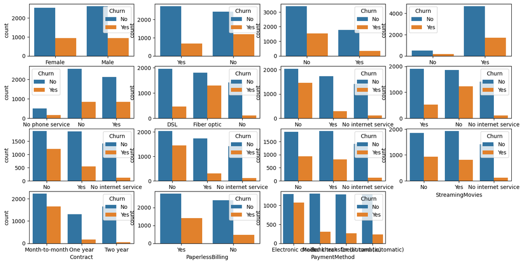

```python
catgory_list =['gender',
 'Partner',
 'Dependents',
 'PhoneService',
 'MultipleLines',
 'InternetService',
 'OnlineSecurity',
 'OnlineBackup',
 'DeviceProtection',
 'TechSupport',
 'StreamingTV',
 'StreamingMovies',
 'Contract',
 'PaperlessBilling',
 'PaymentMethod',
]
print(len(catgory_list))


fig = plt.figure(figsize = (16, 8))

for i in range(len(catgory_list)):
    column = catgory_list[i]
    sub = fig.add_subplot(4,4,i+1)
    chart = sns.countplot(data = df, x = column, hue = "Churn")
```

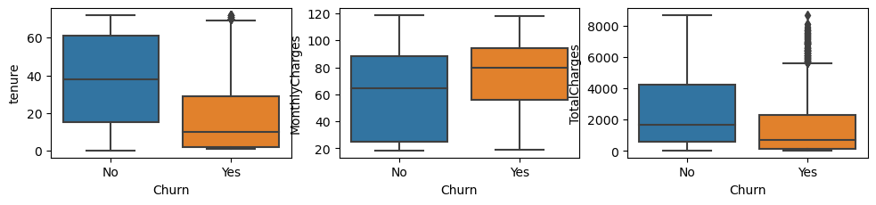

```python
numerical_ = ["tenure", "MonthlyCharges", "TotalCharges"]
fig = plt.figure(figsize = (16,10))

for i in range(len(numerical_)):
    column = numerical_[i]
    sub = fig.add_subplot(4,4,i+1)
    chart = sns.boxplot(data = df, y = column, x = "Churn")
```

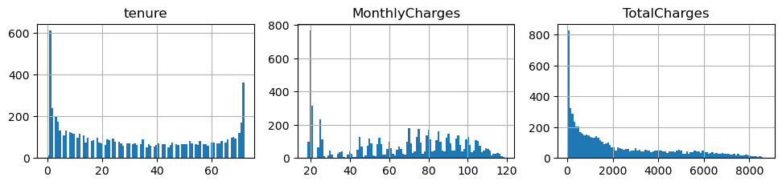

```python
numerical_ = ["tenure", "MonthlyCharges", "TotalCharges"]
fig = plt.figure(figsize = (16,10))

for i in range(len(numerical_)):
    column = numerical_[i]
    sub = fig.add_subplot(4,4,i+1).set_title(numerical_[i])
    chart = df[column].hist(bins = 100)
```

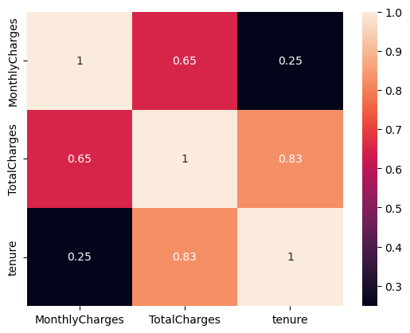

```python
corr_ = df[["MonthlyCharges", "TotalCharges","SeniorCitizen", "tenure"] ].corr()
sns.heatmap(corr_, annot=True)
```

# Fill Null in TotalCharges

In this section, I fill missing data for the 'TotalCharges' feature. To determine the best result, we first check the distribution of this feature and observe that it is skewed. Therefore, we choose to use the median to fill in the missing data.

Another approach to consider is using the most correlated feature(s) to design a model and predict missing values. However, due to time constraints, we were unable to test this approach.

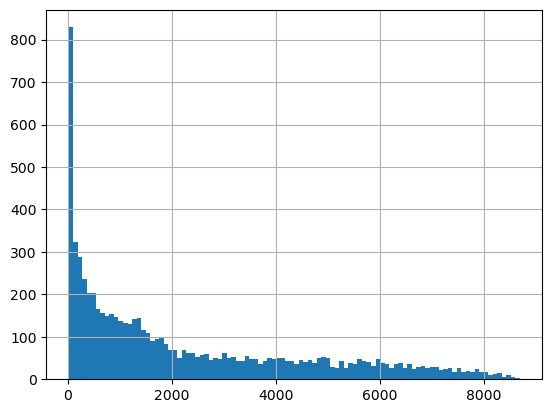

```python
df["TotalCharges"].hist(bins = 100)
```

```python
"""For normally distributed data, the skewness should be about 0.
 A skewness value > 0 means that there is more weight in the left tail of the distribution."""

threshould = 0.5
skew_column = skew(df["TotalCharges"].dropna())
if skew_column > threshould or skew_column < threshould:
    filnan_val = df["TotalCharges"].dropna().median()
else:
    filnan_val = df["TotalCharges"].dropna().mean()


print(skew(df["TotalCharges"].dropna()))
```

```
0.9635838161778828
```

```python
print(df["TotalCharges"].median())
df["TotalCharges"].describe()
```

```
1397.475
```

[output not shown]

```python
df["TotalCharges"].fillna(df["TotalCharges"].median(), inplace = True)
```

```python
df["TotalCharges"].isna().sum()
```

```
0
```

# Categorical to numerical

n this step, we convert categorical features into numerical features using the one-hot-encoding method. This involves creating new binary columns for each category in the original categorical feature, and assigning a value of 1 or 0 depending on whether the category is present in each row. This process allows us to incorporate categorical features into our machine learning models, which typically require numerical data to perform analysis and predictions. Overall, this step helps to improve the accuracy and reliability of our models.

```python
enc = OneHotEncoder( sparse=False).fit(df[categorical_val])

encoded = enc.transform(df[categorical_val])

encoded_df = pd.DataFrame(
     encoded,
     columns=enc.get_feature_names_out()
)
print(encoded_df.shape)

encoded_df[numerical_col] = df[numerical_col]
encoded_df["customerID"] = df["customerID"]
encoded_df[target_col] = df[target_col]
encoded_df["Churn"].replace({"No"},0, inplace = True)
encoded_df["Churn"].replace({"Yes"},1, inplace = True)

encoded_df.head(1)
```

```
(7043, 43)
```

|  | gender_Female | gender_Male | SeniorCitizen_No | SeniorCitizen_Yes | Partner_No | Partner_Yes | Dependents_No | Dependents_Yes | PhoneService_No | PhoneService_Yes | MultipleLines_No | MultipleLines_No phone service | MultipleLines_Yes | InternetService_DSL | InternetService_Fiber optic | InternetService_No | OnlineSecurity_No | OnlineSecurity_No internet service | OnlineSecurity_Yes | OnlineBackup_No | OnlineBackup_No internet service | OnlineBackup_Yes | DeviceProtection_No | DeviceProtection_No internet service | DeviceProtection_Yes | TechSupport_No | TechSupport_No internet service | TechSupport_Yes | StreamingTV_No | … |
| --- | --- | --- | --- | --- | --- | --- | --- | --- | --- | --- | --- | --- | --- | --- | --- | --- | --- | --- | --- | --- | --- | --- | --- | --- | --- | --- | --- | --- | --- | --- |
| 0 | 1.0 | 0.0 | 1.0 | 0.0 | 0.0 | 1.0 | 1.0 | 0.0 | 1.0 | 0.0 | 0.0 | 1.0 | 0.0 | 1.0 | 0.0 | 0.0 | 1.0 | 0.0 | 0.0 | 0.0 | 0.0 | 1.0 | 1.0 | 0.0 | 0.0 | 1.0 | 0.0 | 0.0 | 1.0 | … |

# Splite data for start modeling

In this project, we split the data into three sets: a training set, a validation set, and a test set.

- The training set is used to train different classification models using various algorithms.
- The validation set is used to evaluate the performance of each model on unseen data and to select the model with the best trade-off between bias and variance.
- Finally, the test set is used to assess the performance of the chosen model on completely unseen data and to estimate its performance on new, real-world examples.

By using this three-fold split, we can avoid overfitting and obtain a reliable estimate of the model's performance on new data.

```python
data = encoded_df
data.set_index("customerID", inplace = True)
print(data.shape)

x_train, x_test, y_train, y_test = train_test_split(data.drop(columns = target_col), data[target_col], test_size=0.33, random_state=42)
x_val, x_test, y_val, y_test  = train_test_split(x_test, y_test, test_size=0.4, random_state=42)

print(x_train.shape)
print(x_val.shape)
print(x_test.shape)


print(type(x_train))
print(type(y_train))
```

```
(7043, 47)
(4718, 46)
(1395, 46)
(930, 46)
<class 'pandas.core.frame.DataFrame'>
<class 'pandas.core.frame.DataFrame'>
```

# Models

In this step, we define several classification models and train them on the training set. We then evaluate the performance of each model on both the training set and the validation set to assess their accuracy, precision, recall, and F1 score. We compare the performance of each model to determine which one is the best fit for our data and problem. Some of the models we consider include logistic regression, decision trees, random forests, and support vector machines

## Logistic Regression

```python
reg = LogisticRegression()
reg.fit(x_train, y_train)
y_pre_train_lr = reg.predict(x_train)
y_pre_val_lr = reg.predict(x_val)
```

```
check bias
accuracy:  0.8054260279779568
f1_score:  0.5864864864864865
precision: 0.5245769540692989
recall:    0.6649642492339122
ROC AUC score of Lr: 0.72
```

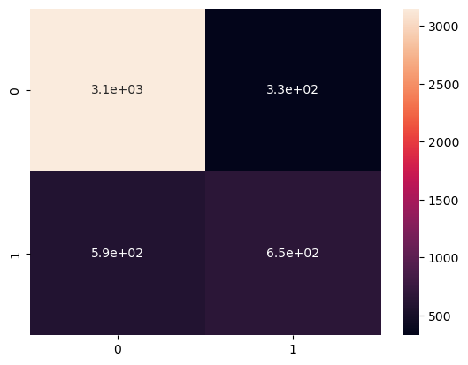

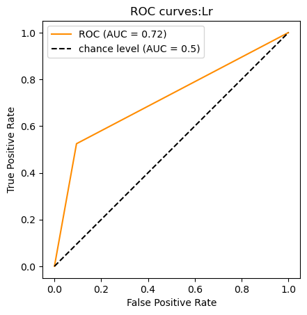

```python
print("check bias")
check_error(y_train, y_pre_train_lr)
ROC_AUC("Lr", y_train, y_pre_train_lr)
```

```
check variance
accuracy:  0.8150537634408602
f1_score:  0.6293103448275862
precision: 0.5718015665796344
recall:    0.6996805111821086
ROC AUC score of Lr: 0.74
```

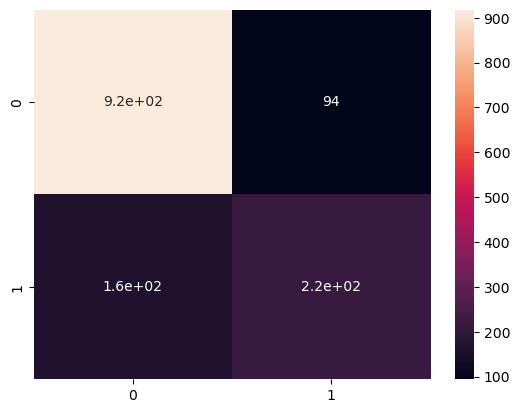

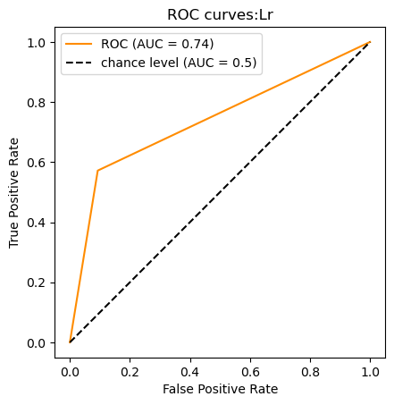

```python
print("check variance")
check_error(y_val, y_pre_val_lr)
ROC_AUC("Lr", y_val, y_pre_val_lr)
```

## SVM

```python
SV = SVC()
SV.fit(x_train, y_train)
y_pre_train_sv = SV.predict(x_train)
y_pre_val_sv = SV.predict(x_val)
```

```
check bias
accuracy:  0.7369648155998304
f1_score:  0.0
precision: 0.0
recall:    0.0
ROC AUC score of Lr: 0.50
```

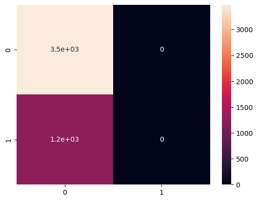

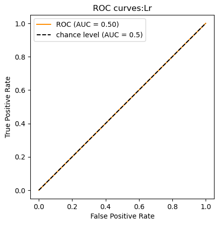

```python
print("check bias")
check_error(y_train, y_pre_train_sv)
ROC_AUC("Lr", y_train, y_pre_train_sv)
```

```
check variance
accuracy:  0.7254480286738352
f1_score:  0.0
precision: 0.0
recall:    0.0
ROC AUC score of Lr: 0.50
```

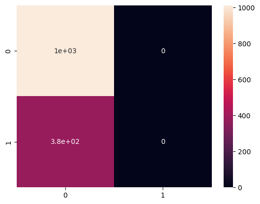

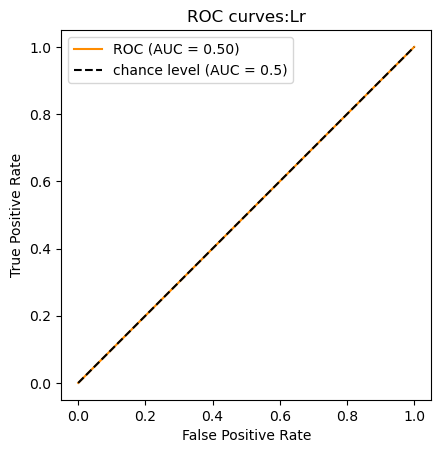

```python
print("check variance")
check_error(y_val, y_pre_val_sv)
ROC_AUC("Lr", y_val, y_pre_val_sv)
```

## KNN

```python
Knn = KNeighborsClassifier().fit(x_train, y_train)
y_pre_train_knn = Knn.predict(x_train)
y_pre_val_knn = Knn.predict(x_val)
```

```
check bias
accuracy:  0.8298007630351844
f1_score:  0.6321575813101236
precision: 0.5560032232070911
recall:    0.732484076433121
ROC AUC score of Lr: 0.74
```

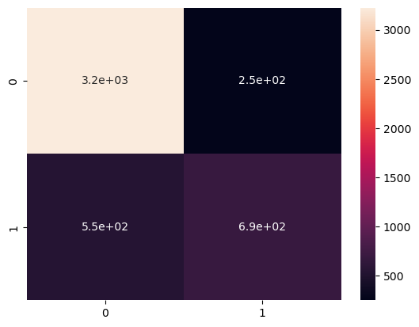

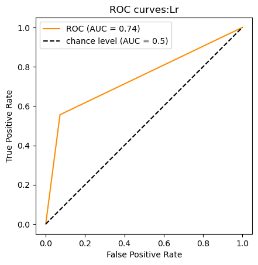

```python
print("check bias")
check_error(y_train, y_pre_train_knn)
ROC_AUC("Lr", y_train, y_pre_train_knn)
```

```
check variance
accuracy:  0.7734767025089606
f1_score:  0.5311572700296736
precision: 0.46736292428198434
recall:    0.6151202749140894
ROC AUC score of Lr: 0.68
```

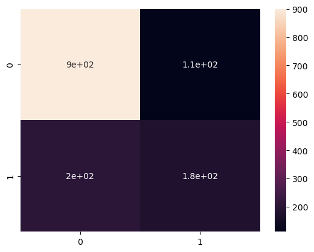

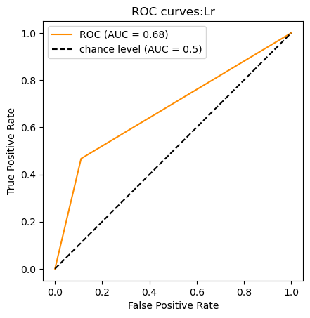

```python
print("check variance")
check_error(y_val, y_pre_val_knn)
ROC_AUC("Lr", y_val, y_pre_val_knn)
```

## Naive Bayes

```python
gnb = GaussianNB().fit(x_train, y_train)
y_pre_train_gnb = Knn.predict(x_train)
y_pre_val_gnb = Knn.predict(x_val)
```

```
check bias
accuracy:  0.8298007630351844
f1_score:  0.6321575813101236
precision: 0.5560032232070911
recall:    0.732484076433121
ROC AUC score of Lr: 0.74
```

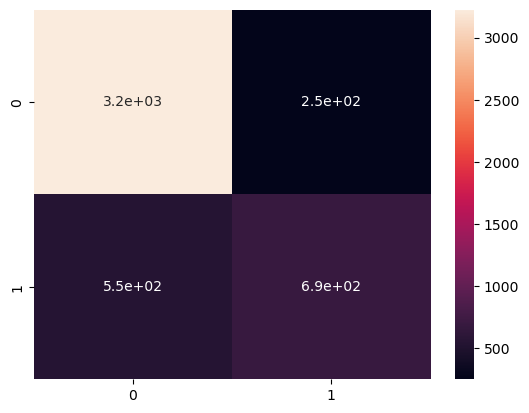

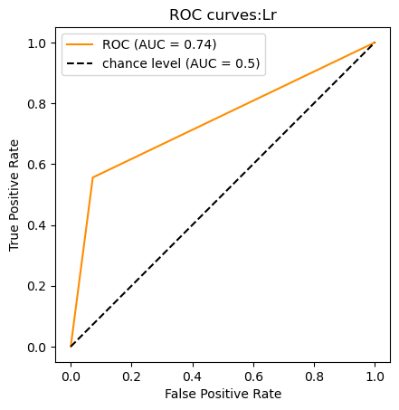

```python
print("check bias")
check_error(y_train, y_pre_train_knn)
ROC_AUC("Lr", y_train, y_pre_train_knn)
```

```
check bias
accuracy:  0.7734767025089606
f1_score:  0.5311572700296736
precision: 0.46736292428198434
recall:    0.6151202749140894
ROC AUC score of Lr: 0.68
```

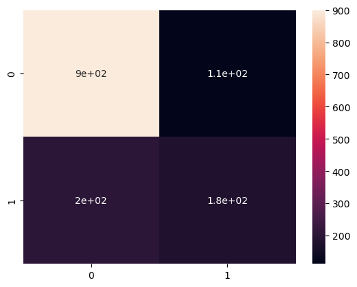

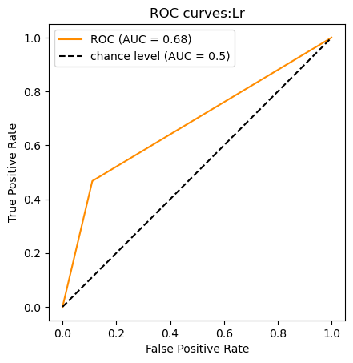

```python
print("check bias")
check_error(y_val, y_pre_val_gnb)
ROC_AUC("Lr", y_val, y_pre_val_gnb)
```

# Compare all models

After training and evaluating multiple classification models on our dataset, we found that the **GradientBoostingClassifier** algorithm had the best performance, likely due to its ability to handle unbalanced data. We saved the accuracy of each model and compared them to determine the best fit for our data. To further analyze the results, we plotted the confusion matrix for each model to see how well they predicted churn. Finally, we tested the chosen model on the test set and achieved an accuracy of more than 75%, indicating that our model is effective at predicting churn in our dataset. Overall, our project demonstrates the importance of analyzing and cleaning data, exploring multiple models, and evaluating their performance to make informed decisions in machine learning

```python
model_pipline = []
#1
model_pipline.append(LogisticRegression())
#2
model_pipline.append(SVC())
#3
model_pipline.append(KNeighborsClassifier())
#4
model_pipline.append(GaussianNB())
#5
model_pipline.append(DecisionTreeClassifier(max_depth=None, min_samples_split=2,random_state=0))
#6
model_pipline.append(RandomForestClassifier(n_estimators=10, max_depth=None,   min_samples_split=2, random_state=0))
#7
model_pipline.append(ExtraTreesClassifier(n_estimators=10, max_depth=None,min_samples_split=2, random_state=0))
#8
model_pipline.append(AdaBoostClassifier(n_estimators=100))
#9
model_pipline.append(GradientBoostingClassifier(n_estimators=100, learning_rate=1.0, max_depth=1, random_state=0))
#10
model_pipline.append(RidgeClassifier())

model_list = ['LogisticRegression',
             ' SVC',
               'KNeighborsClassifier',
               'GaussianNB',
               'DecisionTreeClassifier',
               'RandomForestClassifier',
               'ExtraTreesClassifier',
               'AdaBoostClassifier',
               'GradientBoostingClassifier',
               'RidgeClassifier',
               ]

acc_train_list = []
acc_val_list = []

auc_train_list = []
auc_val_list = []

cm_train_list = []
cm_val_list = []

cros_val_ = []


for model in model_pipline:

    model.fit(x_train, y_train)
    y_pre_train = model.predict(x_train)
    y_pre_val = model.predict(x_val)

    acc_train_list.append(accuracy_score(y_pre_train,y_train, normalize = True ))
    acc_val_list.append(accuracy_score(y_val,y_pre_val, normalize = True ))

    fpr_train, tpr_train, _threshould_train = roc_curve(y_train,y_pre_train)
    fpr_val, tpr_val, _threshould_val = roc_curve(y_val,y_pre_val)


    auc_train_list.append(np.round(auc(fpr_train, tpr_train),2))
    auc_val_list.append(np.round(auc(fpr_val, tpr_val),2))

    cm_train_list.append(confusion_matrix(y_train,y_pre_train))
    cm_val_list.append(confusion_matrix(y_val,y_pre_val))


result_df = pd.DataFrame({
    'Model': model_list,
    'Accurency_train': acc_train_list,
    'Accurency_val': acc_val_list ,
    'AUC_train': auc_train_list,
    'AUC_val':auc_val_list
    })
```

```python
result_df
```

|  | Model | Accurency_train | Accurency_val | AUC_train | AUC_val |
| --- | --- | --- | --- | --- | --- |
| 0 | LogisticRegression | 0.805426 | 0.815054 | 0.72 | 0.74 |
| 1 | SVC | 0.736965 | 0.725448 | 0.50 | 0.50 |
| 2 | KNeighborsClassifier | 0.829801 | 0.773477 | 0.74 | 0.68 |
| 3 | GaussianNB | 0.690123 | 0.703943 | 0.74 | 0.76 |
| 4 | DecisionTreeClassifier | 0.998516 | 0.744803 | 1.00 | 0.68 |
| 5 | RandomForestClassifier | 0.978381 | 0.779928 | 0.96 | 0.68 |
| 6 | ExtraTreesClassifier | 0.998516 | 0.771326 | 1.00 | 0.67 |
| 7 | AdaBoostClassifier | 0.810725 | 0.812903 | 0.72 | 0.73 |
| 8 | GradientBoostingClassifier | 0.813268 | 0.819355 | 0.72 | 0.74 |
| 9 | RidgeClassifier | 0.801399 | 0.812186 | 0.70 | 0.73 |

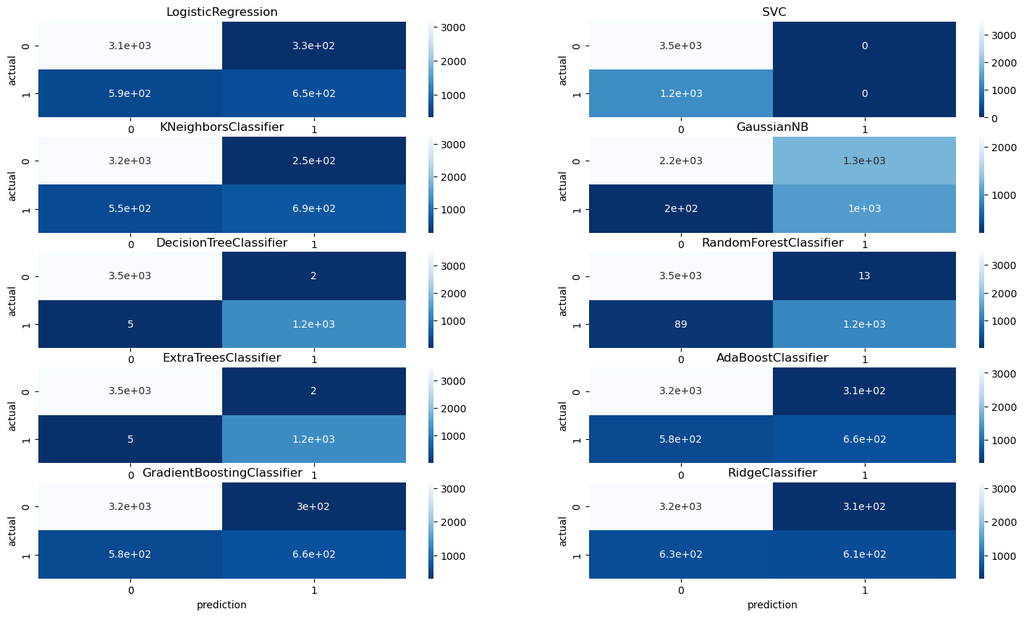

```python
fig = plt.figure(figsize = (18, 10))

for i in range(len(cm_train_list)):
    cm = cm_train_list[i]
    model = model_list[i]
    sub =  fig.add_subplot(5,2,i+1).set_title(model)
    cm_plot = sns.heatmap(cm, annot = True, cmap='Blues_r')
    cm_plot.set_xlabel("prediction")
    cm_plot.set_ylabel("actual")
```

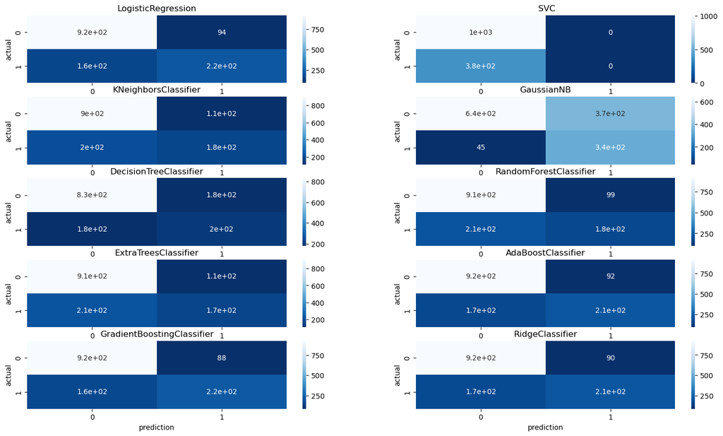

```python
fig = plt.figure(figsize = (18, 10))

for i in range(len(cm_train_list)):
    cm = cm_val_list[i]
    model = model_list[i]
    sub =  fig.add_subplot(5,2,i+1).set_title(model)
    cm_plot = sns.heatmap(cm, annot = True, cmap='Blues_r')
    cm_plot.set_xlabel("prediction")
    cm_plot.set_ylabel("actual")
```

## See result on test set

```
acc : 0.810752688172043
auc : 0.76
```

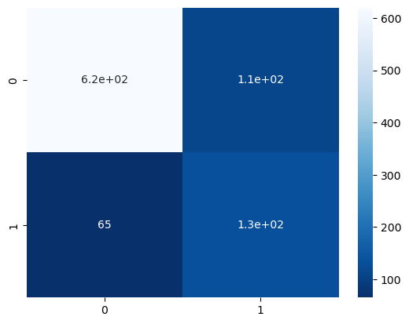

```python
model = GradientBoostingClassifier(n_estimators=100, learning_rate=1.0, max_depth=1, random_state=0)
model.fit(x_train, y_train)
y_pre_test = model.predict(x_test)

acc_ = accuracy_score(y_pre_test,y_test, normalize = True )
fpr_, tpr_, _threshould_train = roc_curve(y_pre_test,y_test)
auc_ = np.round(auc(fpr_, tpr_),2)
cm = confusion_matrix(y_pre_test,y_test)

print("acc :", acc_)
print("auc :", auc_)
sns.heatmap(cm, annot = True, cmap='Blues_r')
```

```python
print(classification_report(y_test, y_pre_test, target_names= ['class 0', 'class 1']))
```

```
              precision    recall  f1-score   support

     class 0       0.85      0.91      0.88       685
     class 1       0.67      0.55      0.60       245

    accuracy                           0.81       930
   macro avg       0.76      0.73      0.74       930
weighted avg       0.80      0.81      0.80       930
```